# Business analytics: churn prediction in Telco

# Predict churn

In order to prevent customer churn, you need to learn to predict in advance which customers may leave us in the future. As almost half of the clients from the clusters *Сinephiles* and *Economic* ones who are leaving the company, I will focus on them.

For the *Сinephiles* cluster, I decided to use the original dataset, without any summed-up variables, as the main difference between these customers is precisely the use of specific services. Therefore, I left only the standardized variables Mothly Charges and tenure.

I am creating two new data sets to create models. The *Сinephiles* clusters and the *Economical* clusters differ in their needs, so they need to be analysed separately. .

```r
# 1st cluster
WA_model = WA_new[,-(5:14)]
WA_model = WA_model %>% dplyr::select(-MonthlyCharges, -all_services)
econom = WA_model %>% filter(Cluster == "1")
econom = WA_model %>% dplyr::select(-Cluster)
econom$Churn = as.factor(econom$Churn)

# 2nd cluster
cinema = WA %>% dplyr::select(-customerID, -TotalCharges, -MonthlyCharges, -tenure)
c = WA_new %>% dplyr::select(MonthlyCharges_stand,tenure_stand,Cluster)
cinema = cbind(cinema,c)
cinema = cinema %>% filter(Cluster == "2") %>% dplyr::select(-Cluster)
cinema$Churn = as.factor(cinema$Churn)
```

Also I need to split the data into training and testing data sets. Exactly 80% of the original cleaned data will be used for training the model and 20% will be used for testing the model.

```r
set.seed(1)
test_ind = createDataPartition(cinema$Churn, p = 0.2, list = FALSE)
cinema.test = cinema[test_ind,]
cinema.train = cinema[-test_ind,]

test_ind = createDataPartition(econom$Churn, p = 0.2, list = FALSE)
econom.test = econom[test_ind,]
econom.train = econom[-test_ind,]
```

## Predict churn for cluster “Сinephiles”

### Create The Model

Finally, it’s time to create and train the model. The statistical model that I will use will be Logistic Regression. This model is good for binary classification.Firstly, I desided to use function stepAIC() from library MASS. This function give me the best one model.

```r
logitModelFull_cinema <- glm(Churn~., family = binomial, cinema.train)

#Build the new model
logitModelFull_cinema_new <- stepAIC(logitModelFull_cinema,trace = 0)
summary(logitModelFull_cinema)
```

```
##
## Call:
## glm(formula = Churn ~ ., family = binomial, data = cinema.train)
##
## Deviance Residuals:
##      Min        1Q    Median        3Q       Max
## -2.02226  -0.96374  -0.00049   0.94332   2.70270
##
## Coefficients: (1 not defined because of singularities)
##                                       Estimate Std. Error z value Pr(>|z|)
## (Intercept)                           -6.55279    2.48829  -2.633  0.00845 **
## genderMale                            -0.22516    0.13397  -1.681  0.09282 .
## SeniorCitizen1                         0.21980    0.16100   1.365  0.17219
## PartnerYes                             0.06317    0.15007   0.421  0.67378
## DependentsYes                         -0.17650    0.18445  -0.957  0.33862
## PhoneServiceYes                        2.04005    1.39375   1.464  0.14327
## MultipleLinesNo phone service               NA         NA      NA       NA
## MultipleLinesYes                       1.03408    0.32473   3.184  0.00145 **
## InternetServiceFiber optic             3.85931    1.49846   2.576  0.01001 *
## OnlineSecurityYes                      0.26099    0.33692   0.775  0.43854
## OnlineBackupYes                        0.49921    0.32077   1.556  0.11964
## DeviceProtectionYes                    0.50118    0.32256   1.554  0.12024
## TechSupportYes                         0.15315    0.33652   0.455  0.64903
## StreamingTVYes                         1.27988    0.59942   2.135  0.03274 *
## StreamingMoviesYes                     1.45675    0.59889   2.432  0.01500 *
## ContractOne year                      -0.53756    0.24043  -2.236  0.02536 *
## ContractTwo year                     -15.07900  367.09277  -0.041  0.96723
## PaperlessBillingYes                    0.51275    0.16206   3.164  0.00156 **
## PaymentMethodCredit card (automatic)   0.08139    0.24140   0.337  0.73598
## PaymentMethodElectronic check          0.37863    0.19134   1.979  0.04784 *
## PaymentMethodMailed check              0.19055    0.26276   0.725  0.46834
## MonthlyCharges_stand                  -3.41179    1.75348  -1.946  0.05169 .
## tenure_stand                          -0.92041    0.15073  -6.106 1.02e-09 ***
## ---
## Signif. codes:  0 '***' 0.001 '**' 0.01 '*' 0.05 '.' 0.1 ' ' 1
##
## (Dispersion parameter for binomial family taken to be 1)
##
##     Null deviance: 1648.0  on 1190  degrees of freedom
## Residual deviance: 1335.6  on 1169  degrees of freedom
## AIC: 1379.6
##
## Number of Fisher Scoring iterations: 15
```

```r
summary(logitModelFull_cinema_new)
```

```
##
## Call:
## glm(formula = Churn ~ gender + SeniorCitizen + MultipleLines +
##     InternetService + OnlineBackup + DeviceProtection + StreamingTV +
##     StreamingMovies + Contract + PaperlessBilling + MonthlyCharges_stand +
##     tenure_stand, family = binomial, data = cinema.train)
##
## Deviance Residuals:
##      Min        1Q    Median        3Q       Max
## -1.99193  -0.98585  -0.00048   0.95266   2.67201
##
## Coefficients:
##                               Estimate Std. Error z value Pr(>|z|)
## (Intercept)                    -3.6609     0.4361  -8.394  < 2e-16 ***
## genderMale                     -0.2111     0.1325  -1.593 0.111141
## SeniorCitizen1                  0.2643     0.1554   1.701 0.088972 .
## MultipleLinesNo phone service  -1.3938     0.8557  -1.629 0.103339
## MultipleLinesYes                0.8651     0.1656   5.224 1.75e-07 ***
## InternetServiceFiber optic      3.0898     0.5246   5.890 3.87e-09 ***
## OnlineBackupYes                 0.3276     0.1686   1.942 0.052089 .
## DeviceProtectionYes             0.3113     0.1687   1.846 0.064932 .
## StreamingTVYes                  0.9832     0.2480   3.965 7.34e-05 ***
## StreamingMoviesYes              1.1480     0.2438   4.709 2.49e-06 ***
## ContractOne year               -0.6033     0.2381  -2.533 0.011298 *
## ContractTwo year              -15.1489   370.0589  -0.041 0.967346
## PaperlessBillingYes             0.5263     0.1607   3.276 0.001054 **
## MonthlyCharges_stand           -2.4768     0.6543  -3.785 0.000153 ***
## tenure_stand                   -0.9587     0.1467  -6.535 6.34e-11 ***
## ---
## Signif. codes:  0 '***' 0.001 '**' 0.01 '*' 0.05 '.' 0.1 ' ' 1
##
## (Dispersion parameter for binomial family taken to be 1)
##
##     Null deviance: 1648.0  on 1190  degrees of freedom
## Residual deviance: 1342.2  on 1176  degrees of freedom
## AIC: 1372.2
##
## Number of Fisher Scoring iterations: 15
```

So the model, which gave me function stepAIC is next: *Churn ~ gender + SeniorCitizen + MultipleLines + InternetService + OnlineBackup + DeviceProtection + StreamingTV + StreamingMovies + Contract + PaperlessBilling + MonthlyCharges_stand + tenure_stand*. AIC is 1372.2, which is less than 1379.6 and should be better.

### Evaluate The Model

To evaluate the logistic regression model, I will print the predictions and look at the test statistics like precision, recall and the f-1 score.

```r
test <- predict(logitModelFull_cinema, cinema.test, type="response")
pred <- factor(ifelse(test > 0.5,"Yes","No"))
confusion <- caret::confusionMatrix(pred, cinema.test$Churn, mode = "prec_recall")
confusion
```

```
## Confusion Matrix and Statistics
##
##           Reference
## Prediction  No Yes
##        No  107  35
##        Yes  50 107
##
##                Accuracy : 0.7157
##                  95% CI : (0.6609, 0.7662)
##     No Information Rate : 0.5251
##     P-Value [Acc > NIR] : 1.293e-11
##
##                   Kappa : 0.4329
##
##  Mcnemar's Test P-Value : 0.1289
##
##               Precision : 0.7535
##                  Recall : 0.6815
##                      F1 : 0.7157
##              Prevalence : 0.5251
##          Detection Rate : 0.3579
##    Detection Prevalence : 0.4749
##       Balanced Accuracy : 0.7175
##
##        'Positive' Class : No
##
```

Recall is about 68%. It means that the model correctly identified 68% of the customers who retained and missed 32%.The precision of the model was about 75% and the f1-score was about 72%. The accuracy of the model was about 71%. Exactly, 107 cluents were true predicted that they don’t churn and 107 cluent were identified as thise who really churn.

Let’s look on the second model:

```r
test <- predict(logitModelFull_cinema_new, cinema.test, type="response")
pred <- factor(ifelse(test > 0.5,"Yes","No"))
confusion <- caret::confusionMatrix(pred, cinema.test$Churn, mode = "prec_recall")
confusion
```

```
## Confusion Matrix and Statistics
##
##           Reference
## Prediction  No Yes
##        No  106  37
##        Yes  51 105
##
##                Accuracy : 0.7057
##                  95% CI : (0.6505, 0.7567)
##     No Information Rate : 0.5251
##     P-Value [Acc > NIR] : 1.459e-10
##
##                   Kappa : 0.4127
##
##  Mcnemar's Test P-Value : 0.1658
##
##               Precision : 0.7413
##                  Recall : 0.6752
##                      F1 : 0.7067
##              Prevalence : 0.5251
##          Detection Rate : 0.3545
##    Detection Prevalence : 0.4783
##       Balanced Accuracy : 0.7073
##
##        'Positive' Class : No
##
```

The results of the second model is little worse, but the significans of predictors are higher. I thing, that I can choose the second one.

The **most** significant values are: 1. MultipleLines 2. InternetService 3. StreamingTVYes  
4. StreamingMoviesYes 5. MonthlyCharges_stand 6. tenure_stand

Exactly, all these variables have the lowest p-values and can be identified as the best predictors of customer churn for the cluents from the cluster *“Сinephiles”*

### Interpretation of the coefficients

```r
Coefficient <- c("MultipleLines(Yes)","InternetService(Fiber optic)", "StreamingTV(Yes) ", "StreamingMovies(Yes)", "MonthlyCharges_stand", "tenure_stand")

Interpretation <- c("Considering that the customer uses multipline lines, the risk of customer churn increases by 2.38 times or by 138% for those who have multipline lines compared to those who do not. Thus, customers with multiline lines, as opposed to those who have one line or no lines at all, are more inclined to churn out.",
                    "Given that a customer uses fibre optics, the risk of customer churn increases by a factor of 21.97 or 2097 % for those who have fibre optics compared to those who have DSL (There are no customers in the analysed cluster who do not use internet at all).",
                    "Given that the customer is using Streaming TV, the risk of customer churn increases by 2.67 times or by 167% for those who have Streaming TV connected than for those who do not use the service.",
                    "Given that the customer is using Streaming Movies, the risk of customer churn increases by 3.15 times or by 215% for those who have Streaming Movies connected than for those who do not use the service.",
                    "An increase of one dollar in MonthlyCharges of customer decreases the risk of churn by 0.08 times or by 92%.",
                    "An increase of one month in customer staying in the company decreases the risk of churn by  0.38 times or by 62%.")

Coef_tab <- data.frame(Coefficient, Interpretation)

formattable(Coef_tab,
            align =c("l","l"),
            list(`Indicator Name` = formatter(
              "span", style = ~ style(color = "grey",font.weight = "bold"))))
```

| Coefficient | Interpretation |
| --- | --- |
| MultipleLines(Yes) | Considering that the customer uses multipline lines, the risk of customer churn increases by 2.38 times or by 138% for those who have multipline lines compared to those who do not. Thus, customers wit… |
| InternetService(Fiber optic) | Given that a customer uses fibre optics, the risk of customer churn increases by a factor of 21.97 or 2097 % for those who have fibre optics compared to those who have DSL (There are no customers in t… |
| StreamingTV(Yes) | Given that the customer is using Streaming TV, the risk of customer churn increases by 2.67 times or by 167% for those who have Streaming TV connected than for those who do not use the service. |
| StreamingMovies(Yes) | Given that the customer is using Streaming Movies, the risk of customer churn increases by 3.15 times or by 215% for those who have Streaming Movies connected than for those who do not use the service… |
| MonthlyCharges_stand | An increase of one dollar in MonthlyCharges of customer decreases the risk of churn by 0.08 times or by 92%. |
| tenure_stand | An increase of one month in customer staying in the company decreases the risk of churn by 0.38 times or by 62%. |

### Create The Model

As I have wrote earlie, for the clients from cluster *“Economical”* I save the variable with sum of all services, because they are not use some of that services actively (exactly, most of them don’t like use any services).

```r
logitModelFull_econom <- glm(Churn~., family = binomial, econom.train)

#Build the new model
logitModelFull_econom_new <- stepAIC(logitModelFull_econom,trace = 0)
summary(logitModelFull_econom)
```

```
##
## Call:
## glm(formula = Churn ~ ., family = binomial, data = econom.train)
##
## Deviance Residuals:
##     Min       1Q   Median       3Q      Max
## -1.8315  -0.6981  -0.3049   0.7438   3.1209
##
## Coefficients:
##                                      Estimate Std. Error z value Pr(>|z|)
## (Intercept)                          -1.35487    0.12304 -11.011  < 2e-16 ***
## genderMale                           -0.02655    0.07138  -0.372 0.709919
## SeniorCitizen1                        0.34213    0.09336   3.665 0.000248 ***
## PartnerYes                            0.07658    0.08541   0.897 0.369953
## DependentsYes                        -0.31835    0.09881  -3.222 0.001274 **
## ContractOne year                     -0.85359    0.11711  -7.289 3.13e-13 ***
## ContractTwo year                     -1.55308    0.19041  -8.156 3.45e-16 ***
## PaperlessBillingYes                   0.38886    0.08084   4.810 1.51e-06 ***
## PaymentMethodCredit card (automatic) -0.07018    0.12655  -0.555 0.579204
## PaymentMethodElectronic check         0.38970    0.10378   3.755 0.000173 ***
## PaymentMethodMailed check            -0.10931    0.12332  -0.886 0.375438
## MonthlyCharges_stand                  0.85553    0.09669   8.848  < 2e-16 ***
## tenure_stand                         -0.84424    0.06334 -13.329  < 2e-16 ***
## all_services_stnd                    -0.26017    0.10650  -2.443 0.014568 *
## ---
## Signif. codes:  0 '***' 0.001 '**' 0.01 '*' 0.05 '.' 0.1 ' ' 1
##
## (Dispersion parameter for binomial family taken to be 1)
##
##     Null deviance: 6513.9  on 5624  degrees of freedom
## Residual deviance: 4802.2  on 5611  degrees of freedom
## AIC: 4830.2
##
## Number of Fisher Scoring iterations: 6
```

```r
summary(logitModelFull_econom_new)
```

```
##
## Call:
## glm(formula = Churn ~ SeniorCitizen + Dependents + Contract +
##     PaperlessBilling + PaymentMethod + MonthlyCharges_stand +
##     tenure_stand + all_services_stnd, family = binomial, data = econom.train)
##
## Deviance Residuals:
##     Min       1Q   Median       3Q      Max
## -1.8476  -0.6987  -0.3050   0.7380   3.0944
##
## Coefficients:
##                                      Estimate Std. Error z value Pr(>|z|)
## (Intercept)                          -1.34056    0.11420 -11.739  < 2e-16 ***
## SeniorCitizen1                        0.35176    0.09270   3.795 0.000148 ***
## DependentsYes                        -0.28159    0.08961  -3.142 0.001676 **
## ContractOne year                     -0.85195    0.11710  -7.276 3.45e-13 ***
## ContractTwo year                     -1.55331    0.19041  -8.158 3.41e-16 ***
## PaperlessBillingYes                   0.38829    0.08081   4.805 1.55e-06 ***
## PaymentMethodCredit card (automatic) -0.07417    0.12643  -0.587 0.557406
## PaymentMethodElectronic check         0.38736    0.10372   3.735 0.000188 ***
## PaymentMethodMailed check            -0.11538    0.12316  -0.937 0.348847
## MonthlyCharges_stand                  0.85629    0.09664   8.861  < 2e-16 ***
## tenure_stand                         -0.83344    0.06199 -13.444  < 2e-16 ***
## all_services_stnd                    -0.25868    0.10644  -2.430 0.015084 *
## ---
## Signif. codes:  0 '***' 0.001 '**' 0.01 '*' 0.05 '.' 0.1 ' ' 1
##
## (Dispersion parameter for binomial family taken to be 1)
##
##     Null deviance: 6513.9  on 5624  degrees of freedom
## Residual deviance: 4803.1  on 5613  degrees of freedom
## AIC: 4827.1
##
## Number of Fisher Scoring iterations: 6
```

So the model, which gave me function stepAIC is next: *Churn ~ SeniorCitizen + Dependents + Contract + PaperlessBilling + PaymentMethod + MonthlyCharges_stand + tenure_stand + all_services_stnd*. AIC is 4827.1, which is less than 4830.2 and should be better.

### Evaluate The Model

To evaluate the logistic regression model, I will print the predictions and look at the test statistics like precision, recall and the f-1 score.

```r
test <- predict(logitModelFull_econom, econom.test, type="response")
pred <- factor(ifelse(test > 0.5,"Yes","No"))
confusion <- caret::confusionMatrix(pred, econom.test$Churn, mode = "prec_recall")
confusion
```

```
## Confusion Matrix and Statistics
##
##           Reference
## Prediction  No Yes
##        No  929 177
##        Yes 104 197
##
##                Accuracy : 0.8003
##                  95% CI : (0.7784, 0.8209)
##     No Information Rate : 0.7342
##     P-Value [Acc > NIR] : 4.549e-09
##
##                   Kappa : 0.4543
##
##  Mcnemar's Test P-Value : 1.746e-05
##
##               Precision : 0.8400
##                  Recall : 0.8993
##                      F1 : 0.8686
##              Prevalence : 0.7342
##          Detection Rate : 0.6603
##    Detection Prevalence : 0.7861
##       Balanced Accuracy : 0.7130
##
##        'Positive' Class : No
##
```

Let’s look on the second model:

```r
test <- predict(logitModelFull_econom_new, econom.test, type="response")
pred <- factor(ifelse(test > 0.5,"Yes","No"))
confusion <- caret::confusionMatrix(pred, econom.test$Churn, mode = "prec_recall")
confusion
```

```
## Confusion Matrix and Statistics
##
##           Reference
## Prediction  No Yes
##        No  927 176
##        Yes 106 198
##
##                Accuracy : 0.7996
##                  95% CI : (0.7777, 0.8202)
##     No Information Rate : 0.7342
##     P-Value [Acc > NIR] : 6.639e-09
##
##                   Kappa : 0.4539
##
##  Mcnemar's Test P-Value : 3.976e-05
##
##               Precision : 0.8404
##                  Recall : 0.8974
##                      F1 : 0.8680
##              Prevalence : 0.7342
##          Detection Rate : 0.6588
##    Detection Prevalence : 0.7839
##       Balanced Accuracy : 0.7134
##
##        'Positive' Class : No
##
```

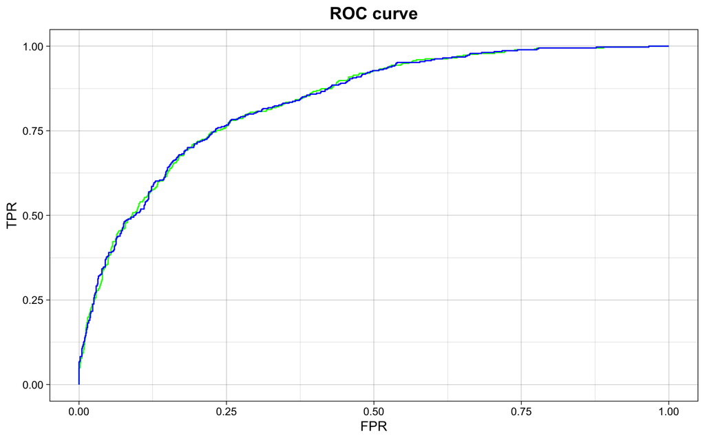

```r
log.model.econom = glm(Churn~., data = econom.train, family = binomial(link = 'logit'))
pred1 = predict(log.model.econom, newdata = econom.test, type = "response")
ROC_econom1 = roc(response = econom.test$Churn, predictor = pred1)

log.model.econom2 = glm(Churn ~ SeniorCitizen + Dependents + Contract + PaperlessBilling + PaymentMethod + MonthlyCharges_stand + tenure_stand, data = econom.train, family = binomial(link = 'logit'))
pred2 = predict(log.model.econom2, newdata = econom.test, type = "response")
ROC_econom2 = roc(response = econom.test$Churn, predictor = pred2)

ggplot() + geom_path(aes(y=ROC_econom1$sensitivities, x=1-ROC_econom1$specificities), color = "green") +
  geom_path(aes(y=ROC_econom2$sensitivities, x=1-ROC_econom2$specificities), color = "blue") + labs(title = "ROC curve") + xlab("FPR") + ylab("TPR") + theme_linedraw() +theme(plot.title = element_text(size=14, hjust = 0.5, face="bold"))
```

```r
pROC::auc(ROC_econom1)
```

```
## Area under the curve: 0.8364
```

```r
pROC::auc(ROC_econom2)
```

```
## Area under the curve: 0.8365
```

The **most** significant values are: 1. SeniorCitizen1 2. ContractOne year 3. ContractTwo year  
4. PaperlessBillingYes 5. PaymentMethodElectronic check 6. MonthlyCharges_stand 7. tenure_stand